# PROBLEM STATEMENT:

### Our goal here is to attempt FMNIST Classification with Dense Neural Networks (using Tensorflow). We will be doing this with three different models, chosen by changing the hyperparameters. We will also use some metrics to choose the best performiong model and then evaluate the performance of our chosen model.

### GET THE DATA

```python
from tensorflow import keras
from tensorflow.keras import layers
import tensorflow as tf
import pandas as pd
import numpy as np
from sklearn.model_selection import train_test_split

train_set = pd.read_csv(r"C:\Users\emekamichael\Downloads\fashion-mnist_train.csv\fashion-mnist_train.csv")
test_set = pd.read_csv(r"C:\Users\emekamichael\Downloads\fashion-mnist_test.csv\fashion-mnist_test.csv")


# Separate features and labels
train_images = train_set.drop('label', axis=1).values
train_labels = train_set['label'].values

test_images = test_set.drop('label', axis=1).values
test_labels = test_set['label'].values
```

### EDA

```python
train_set.head()
```

|  | label | pixel1 | pixel2 | pixel3 | pixel4 | pixel5 | pixel6 | pixel7 | pixel8 | pixel9 | ... | pixel775 | pixel776 | pixel777 | pixel778 | pixel779 | pixel780 | pixel781 | pixel782 | pixel783 | pixel784 |
| --- | --- | --- | --- | --- | --- | --- | --- | --- | --- | --- | --- | --- | --- | --- | --- | --- | --- | --- | --- | --- | --- |
| 0 | 2 | 0 | 0 | 0 | 0 | 0 | 0 | 0 | 0 | 0 | ... | 0 | 0 | 0 | 0 | 0 | 0 | 0 | 0 | 0 | 0 |
| 1 | 9 | 0 | 0 | 0 | 0 | 0 | 0 | 0 | 0 | 0 | ... | 0 | 0 | 0 | 0 | 0 | 0 | 0 | 0 | 0 | 0 |
| 2 | 6 | 0 | 0 | 0 | 0 | 0 | 0 | 0 | 5 | 0 | ... | 0 | 0 | 0 | 30 | 43 | 0 | 0 | 0 | 0 | 0 |
| 3 | 0 | 0 | 0 | 0 | 1 | 2 | 0 | 0 | 0 | 0 | ... | 3 | 0 | 0 | 0 | 0 | 1 | 0 | 0 | 0 | 0 |
| 4 | 3 | 0 | 0 | 0 | 0 | 0 | 0 | 0 | 0 | 0 | ... | 0 | 0 | 0 | 0 | 0 | 0 | 0 | 0 | 0 | 0 |

5 rows × 785 columns

```python
train_set.describe()
```

|  | label | pixel1 | pixel2 | pixel3 | pixel4 | pixel5 | pixel6 | pixel7 | pixel8 | pixel9 | ... | pixel775 | pixel776 | pixel777 | pixel778 | pixel779 | pixel780 | pixel781 | pixel782 | pixel783 | pixel784 |
| --- | --- | --- | --- | --- | --- | --- | --- | --- | --- | --- | --- | --- | --- | --- | --- | --- | --- | --- | --- | --- | --- |
| count | 60000.000000 | 60000.000000 | 60000.000000 | 60000.000000 | 60000.000000 | 60000.000000 | 60000.000000 | 60000.000000 | 60000.000000 | 60000.000000 | ... | 60000.000000 | 60000.000000 | 60000.000000 | 60000.000000 | 60000.000000 | 60000.000000 | 60000.000000 | 60000.000000 | 60000.000000 | 60000.00000 |
| mean | 4.500000 | 0.000900 | 0.006150 | 0.035333 | 0.101933 | 0.247967 | 0.411467 | 0.805767 | 2.198283 | 5.682000 | ... | 34.625400 | 23.300683 | 16.588267 | 17.869433 | 22.814817 | 17.911483 | 8.520633 | 2.753300 | 0.855517 | 0.07025 |
| std | 2.872305 | 0.094689 | 0.271011 | 1.222324 | 2.452871 | 4.306912 | 5.836188 | 8.215169 | 14.093378 | 23.819481 | ... | 57.545242 | 48.854427 | 41.979611 | 43.966032 | 51.830477 | 45.149388 | 29.614859 | 17.397652 | 9.356960 | 2.12587 |
| min | 0.000000 | 0.000000 | 0.000000 | 0.000000 | 0.000000 | 0.000000 | 0.000000 | 0.000000 | 0.000000 | 0.000000 | ... | 0.000000 | 0.000000 | 0.000000 | 0.000000 | 0.000000 | 0.000000 | 0.000000 | 0.000000 | 0.000000 | 0.00000 |
| 25% | 2.000000 | 0.000000 | 0.000000 | 0.000000 | 0.000000 | 0.000000 | 0.000000 | 0.000000 | 0.000000 | 0.000000 | ... | 0.000000 | 0.000000 | 0.000000 | 0.000000 | 0.000000 | 0.000000 | 0.000000 | 0.000000 | 0.000000 | 0.00000 |
| 50% | 4.500000 | 0.000000 | 0.000000 | 0.000000 | 0.000000 | 0.000000 | 0.000000 | 0.000000 | 0.000000 | 0.000000 | ... | 0.000000 | 0.000000 | 0.000000 | 0.000000 | 0.000000 | 0.000000 | 0.000000 | 0.000000 | 0.000000 | 0.00000 |
| 75% | 7.000000 | 0.000000 | 0.000000 | 0.000000 | 0.000000 | 0.000000 | 0.000000 | 0.000000 | 0.000000 | 0.000000 | ... | 58.000000 | 9.000000 | 0.000000 | 0.000000 | 0.000000 | 0.000000 | 0.000000 | 0.000000 | 0.000000 | 0.00000 |
| max | 9.000000 | 16.000000 | 36.000000 | 226.000000 | 164.000000 | 227.000000 | 230.000000 | 224.000000 | 255.000000 | 254.000000 | ... | 255.000000 | 255.000000 | 255.000000 | 255.000000 | 255.000000 | 255.000000 | 255.000000 | 255.000000 | 255.000000 | 170.00000 |

8 rows × 785 columns

```python
# Check data types
print("Data Types:")
print(train_set.dtypes)
```

```
Data Types:
label       int64
pixel1      int64
pixel2      int64
pixel3      int64
pixel4      int64
            ...
pixel780    int64
pixel781    int64
pixel782    int64
pixel783    int64
pixel784    int64
Length: 785, dtype: object
```

```python
# Check for missing values
print("\nMissing Values:")
print(train_set.isnull().sum())
```

```
Missing Values:
label       0
pixel1      0
pixel2      0
pixel3      0
pixel4      0
           ..
pixel780    0
pixel781    0
pixel782    0
pixel783    0
pixel784    0
Length: 785, dtype: int64
```

```python
# Check class distribution
print("\nClass Distribution:")
print(train_set['label'].value_counts())
```

```
Class Distribution:
label
2    6000
9    6000
6    6000
0    6000
3    6000
4    6000
5    6000
8    6000
7    6000
1    6000
Name: count, dtype: int64
```

### Comment:

### class distribution is balanced with all classes having 6,000 observations

# DATA PREPROCESSING

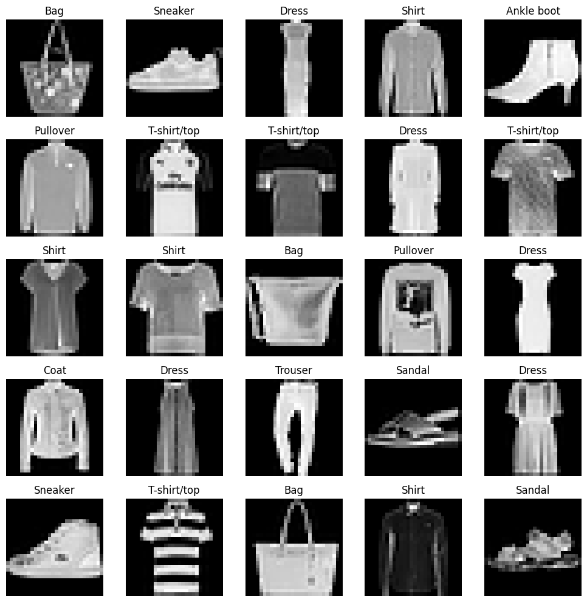

```python
import matplotlib.pyplot as plt


train_images = train_images.reshape((-1, 28 * 28))  # flattening the 28x28 image into dim=1 (784,) vector (and over all images in the training set)
test_images = test_images.reshape((-1, 28 * 28))

train_images = train_images.astype("float32") / 255  # normalizing the data to the range [0,1] by min-max range, and casting it to float32
test_images = test_images.astype("float32") / 255

class_names = ['T-shirt/top', 'Trouser', 'Pullover', 'Dress', 'Coat',
               'Sandal', 'Shirt', 'Sneaker', 'Bag', 'Ankle boot']


def display_random_samples(data, labels, class_names, num_samples=25, figsize=(10, 10)):
    # Generate random indices
    random_indices = np.random.choice(len(data), num_samples, replace=False)

    # Create subplots
    rows = int(np.sqrt(num_samples))
    cols = int(np.ceil(num_samples / rows))
    fig, axes = plt.subplots(rows, cols, figsize=figsize)

    # Plot each sample
    for i, idx in enumerate(random_indices):
        row = i // cols
        col = i % cols
        ax = axes[row, col] if rows > 1 else axes[col]
        # Reshape the flattened image data to its original shape (28x28)
        image = data[idx].reshape(28, 28)
        ax.imshow(image, cmap='gray')
        ax.set_title(class_names[labels[idx]])
        ax.axis('off')

    plt.tight_layout()
    plt.show()

# Display random samples
display_random_samples(train_images, train_labels, class_names)
```

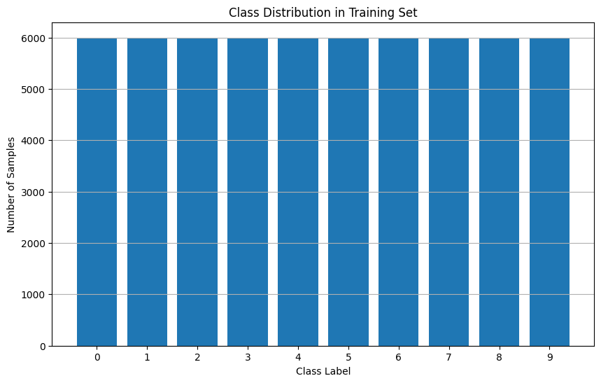

```python
import matplotlib.pyplot as plt

# Count the number of samples for each class
class_counts = train_set['label'].value_counts().sort_index()

# Plotting
plt.figure(figsize=(10, 6))
plt.bar(class_counts.index, class_counts.values)
plt.xlabel('Class Label')
plt.ylabel('Number of Samples')
plt.title('Class Distribution in Training Set')
plt.xticks(class_counts.index)
plt.grid(axis='y')
plt.show()
```

### from the bar plot above, we can see that the distribuiton is even

# MODEL TRAINING

### NEURAL NETWORK 1

```python
from tensorflow import keras
from tensorflow.keras import layers

# Define the model architecture
model = keras.Sequential([
    layers.Dense(128, activation='relu', input_shape=(784,)),
    layers.Dense(64, activation='relu'),
    layers.Dense(10, activation='softmax')
])

# Compile the model
model.compile(optimizer='adam',  # Using the Adam optimizer
              loss='sparse_categorical_crossentropy',  # sparse categorical crossentropy loss function for multi-class classification
              metrics=['accuracy'])  # Track accuracy as the evaluation metric

# Train the model
history = model.fit(train_images, train_labels,  epochs=10,  batch_size=64,  validation_split=0.2)
```

## Inference: Using the Model to Make Predictions

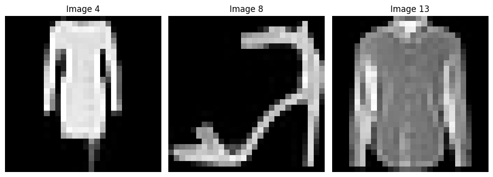

```python
import matplotlib.pyplot as plt

# Select three images from the test dataset (change the indices as needed)
image_indices = [4, 8, 13]

# Create subplots for each image
fig, axes = plt.subplots(1, 3, figsize=(10, 4))

# Plot each image
for i, idx in enumerate(image_indices):
    ax = axes[i]
    ax.imshow(test_images[idx].reshape(28, 28), cmap='gray')
    ax.set_title(f"Image {idx}")
    ax.axis('off')

plt.tight_layout()
plt.show()
```

```python
# List of class names
class_names = ['T-shirt/top', 'Trouser', 'Pullover', 'Dress', 'Coat',
               'Sandal', 'Shirt', 'Sneaker', 'Bag', 'Ankle boot']

# Select the indices of the images you want to predict on
image_indices = [6, 8, 13]

# Select the corresponding images from the test dataset
images_to_predict = test_images[image_indices]

# Make predictions for the selected images
predictions = model.predict(images_to_predict)

# Get the predicted class labels
predicted_labels = predictions.argmax(axis=1)

# Map predicted class indices to class names
predicted_labels_names = [class_names[idx] for idx in predicted_labels]

# Print the predicted class labels
print(predicted_labels_names)
```

```
['Bag', 'Sandal', 'Shirt']
```

```python
# List of class names
class_names = ['T-shirt/top', 'Trouser', 'Pullover', 'Dress', 'Coat',
               'Sandal', 'Shirt', 'Sneaker', 'Bag', 'Ankle boot']

# Select the indices of the images you want to retrieve actual labels for
image_indices = [6, 8, 13]

# Retrieve the actual labels for the selected images
actual_labels = test_labels[image_indices]

# Map actual class indices to class names
actual_labels_names = [class_names[idx] for idx in actual_labels]

# Print the actual class labels
print(actual_labels_names)
```

```
['Bag', 'Sandal', 'Shirt']
```

### Neural Network 2: Changed the Number of Neurons

```python
# Define the model architecture
model_2 = keras.Sequential([
    layers.Dense(256, activation='relu', input_shape=(784,)),
    layers.Dense(128, activation='relu'),
    layers.Dense(10, activation='softmax')
])

# Compile the model
model_2.compile(optimizer='adam', loss='sparse_categorical_crossentropy', metrics=['accuracy'])
# Train the model
history_2 = model_2.fit(train_images, train_labels,  epochs=10,  batch_size=64,  validation_split=0.2)
```

### Neural Network 3: Varying Activation Functions

```python
# Define the model architecture
model_3 = keras.Sequential([
    layers.Dense(128, activation='tanh', input_shape=(784,)),
    layers.Dense(64, activation='sigmoid'),
    layers.Dense(10, activation='softmax')
])

# Compile the model
model_3.compile(optimizer='adam', loss='sparse_categorical_crossentropy', metrics=['accuracy'])
# Train the model
history_3 = model_3.fit(train_images, train_labels,  epochs=10,  batch_size=64,  validation_split=0.2)
```

# EVALUATION ON THE 3 MODELS

```python
# Evaluate the models on the test set
evaluation_1 = model.evaluate(test_images, test_labels)
evaluation_2 = model_2.evaluate(test_images, test_labels)
evaluation_3 = model_3.evaluate(test_images, test_labels)
```

```python
# Extract accuracy from evaluation results
accuracy_1 = evaluation_1[1]
accuracy_2 = evaluation_2[1]
accuracy_3 = evaluation_3[1]

# Print accuracy of each model
print("Model 1 Accuracy:", accuracy_1)
print("Model 2 Accuracy:", accuracy_2)
print("Model 3 Accuracy:", accuracy_3)

# You can also extract other metrics (precision, recall, etc.) from the evaluation results and compare them similarly
```

```
Model 1 Accuracy: 0.8907999992370605
Model 2 Accuracy: 0.8841000199317932
Model 3 Accuracy: 0.8891000151634216
```

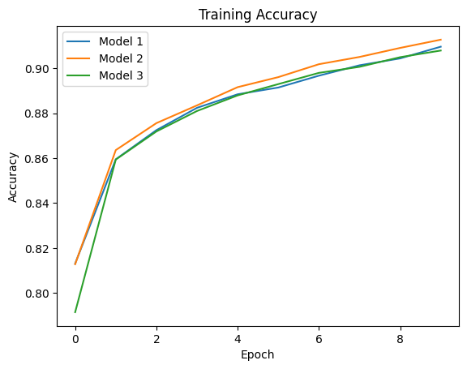

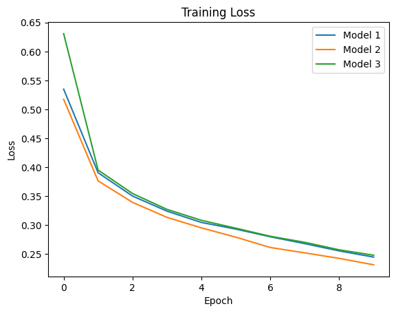

```python
import matplotlib.pyplot as plt

# Plot training history for accuracy
plt.plot(history.history['accuracy'], label='Model 1')
plt.plot(history_2.history['accuracy'], label='Model 2')
plt.plot(history_3.history['accuracy'], label='Model 3')
plt.title('Training Accuracy')
plt.xlabel('Epoch')
plt.ylabel('Accuracy')
plt.legend()
plt.show()

# Plot training history for loss
plt.plot(history.history['loss'], label='Model 1')
plt.plot(history_2.history['loss'], label='Model 2')
plt.plot(history_3.history['loss'], label='Model 3')
plt.title('Training Loss')
plt.xlabel('Epoch')
plt.ylabel('Loss')
plt.legend()
plt.show()
```

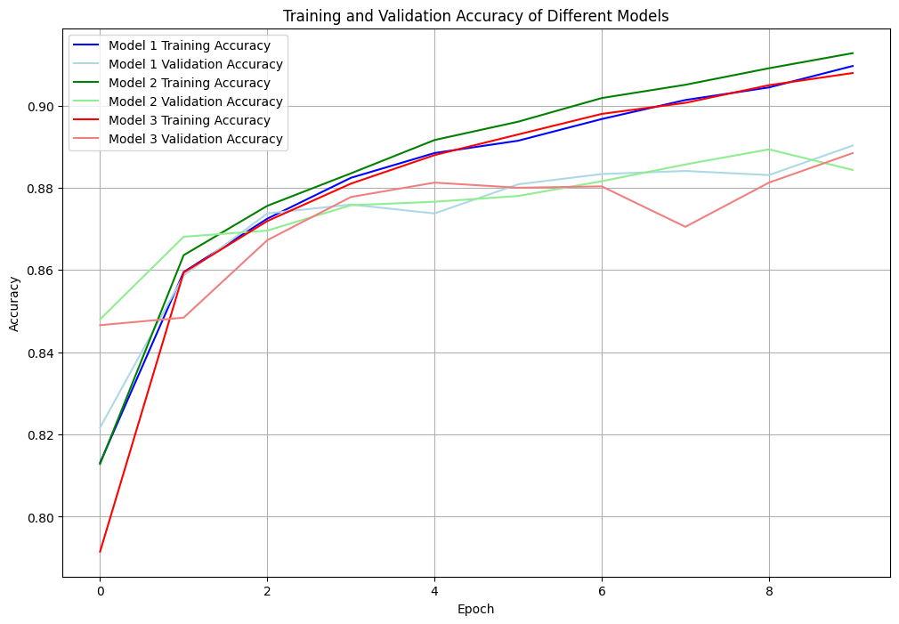

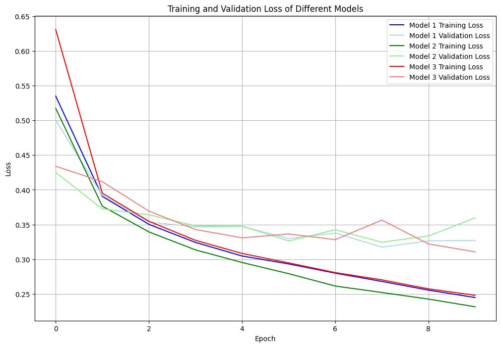

```python
import matplotlib.pyplot as plt

# Plot training and validation accuracy for each model
plt.figure(figsize=(12, 8))
plt.plot(history.history['accuracy'], label='Model 1 Training Accuracy', color='blue')
plt.plot(history.history['val_accuracy'], label='Model 1 Validation Accuracy', color='lightblue')

plt.plot(history_2.history['accuracy'], label='Model 2 Training Accuracy', color='green')
plt.plot(history_2.history['val_accuracy'], label='Model 2 Validation Accuracy', color='lightgreen')

plt.plot(history_3.history['accuracy'], label='Model 3 Training Accuracy', color='red')
plt.plot(history_3.history['val_accuracy'], label='Model 3 Validation Accuracy', color='lightcoral')

plt.title('Training and Validation Accuracy of Different Models')
plt.xlabel('Epoch')
plt.ylabel('Accuracy')
plt.legend()
plt.grid(True)
plt.show()

# Plot training and validation loss for each model
plt.figure(figsize=(12, 8))
plt.plot(history.history['loss'], label='Model 1 Training Loss', color='blue')
plt.plot(history.history['val_loss'], label='Model 1 Validation Loss', color='lightblue')

plt.plot(history_2.history['loss'], label='Model 2 Training Loss', color='green')
plt.plot(history_2.history['val_loss'], label='Model 2 Validation Loss', color='lightgreen')

plt.plot(history_3.history['loss'], label='Model 3 Training Loss', color='red')
plt.plot(history_3.history['val_loss'], label='Model 3 Validation Loss', color='lightcoral')

plt.title('Training and Validation Loss of Different Models')
plt.xlabel('Epoch')
plt.ylabel('Loss')
plt.legend()
plt.grid(True)
plt.show()
```

### 2. Model 2 validation loss (bright green) seems to fluctuate(going up and down) after epoch 2. I wil set the weight here to avoid overfitting the model'

```python
#Implementation of the identified best epochs

# Set the best weights for each model based on the chosen epochs
best_epoch_1 = 5  # Chosen epoch for Model 1
best_epoch_2 = 2  # Chosen epoch for Model 2
best_epoch_3 = 5  # Chosen epoch for Model 3

# Get the weights for each model at the chosen epochs
best_weights_1 = history.model.get_weights()
best_weights_2 = history_2.model.get_weights()
best_weights_3 = history_3.model.get_weights()

# Set the weights of each model to the best weights
model.set_weights(best_weights_1)
model_2.set_weights(best_weights_2)
model_3.set_weights(best_weights_3)
```

```python
import pandas as pd

# Create a DataFrame to store the validation loss and accuracy for each model
data = {
    'Model': ['Model 1', 'Model 2', 'Model 3'],
    'Validation Loss': [history.history['val_loss'][-1], history_2.history['val_loss'][-1], history_3.history['val_loss'][-1]],
    'Validation Accuracy': [history.history['val_accuracy'][-1], history_2.history['val_accuracy'][-1], history_3.history['val_accuracy'][-1]]
}

df = pd.DataFrame(data)

# Display the DataFrame
print(df)
```

```
     Model  Validation Loss  Validation Accuracy
0  Model 1         0.327067             0.890250
1  Model 2         0.359624             0.884333
2  Model 3         0.310598             0.888417
```

```python
from sklearn.metrics import classification_report

# Make predictions on the test set
predictions = model.predict(test_images)

# Convert predictions from probabilities to class labels
predicted_labels = predictions.argmax(axis=1)

# Generate the classification report
report = classification_report(test_labels, predicted_labels, target_names=class_names)

# Print the classification report
print(report)
```

```
              precision    recall  f1-score   support

 T-shirt/top       0.77      0.90      0.83      1000
     Trouser       0.99      0.98      0.99      1000
    Pullover       0.82      0.81      0.82      1000
       Dress       0.92      0.91      0.91      1000
        Coat       0.82      0.85      0.83      1000
      Sandal       0.96      0.96      0.96      1000
       Shirt       0.76      0.63      0.69      1000
     Sneaker       0.93      0.94      0.94      1000
         Bag       0.98      0.96      0.97      1000
  Ankle boot       0.96      0.95      0.95      1000

    accuracy                           0.89     10000
   macro avg       0.89      0.89      0.89     10000
weighted avg       0.89      0.89      0.89     10000
```

```python
from sklearn.metrics import precision_score

# Set the desired class
desired_class = 5

# Compute precision for class '5' using original predictions and true labels
original_precision = precision_score(test_labels == desired_class, predictions[:, desired_class] >= 0.5)  # Assuming original threshold was 0.5

# Set a higher threshold for predicting class '5'
threshold = 0.9  # Adjust the threshold as needed

# Create adjusted predictions based on the threshold
adjusted_predictions = predictions[:, desired_class] >= threshold

# Compute precision for class '5' using adjusted predictions and true labels
adjusted_precision = precision_score(test_labels == desired_class, adjusted_predictions)

# Print the precisions before and after the threshold adjustment
print(f'Original Precision for class 5: {original_precision}')
print(f'Improved Precision for class 5: {adjusted_precision}')
```

```
Original Precision for class 5: 0.9630369630369631
Improved Precision for class 5: 0.9808917197452229
```

```python
from sklearn.metrics import recall_score

# Set the desired class
desired_class = 5

# Compute recall for class '5' using original predictions and true labels
original_recall = recall_score(test_labels == desired_class, predictions[:, desired_class] >= 0.5)  # Assuming original threshold was 0.5

# Set a lower threshold for predicting class '5' (to capture more positive instances)
threshold = 0.3  # Adjust the threshold as needed

# Create adjusted predictions based on the threshold
adjusted_predictions = predictions[:, desired_class] >= threshold

# Compute recall for class '5' using adjusted predictions and true labels
adjusted_recall = recall_score(test_labels == desired_class, adjusted_predictions)

# Print the recalls before and after the threshold adjustment
print(f'Original Recall for class 5: {original_recall}')
print(f'Improved Recall for class 5: {adjusted_recall}')


#
```

```
Original Recall for class 5: 0.964
Improved Recall for class 5: 0.976
```

### Inference: To get an improved Recall, we reduce the threshold

### To get an improved Precision, we increase the threshold.

### Depending on the use case and what we desire to achieve in our prediction, this becomes a powerful tool in our model training.

# CONCLUSION:

### our experiments in developing and evaluating multiple neural network models for fashion image classification using the Fashion MNIST dataset have provided valuable insights.

### we observed that the choice of model architecture and hyperparameters has the potential to impact the performance of a model. Through careful experimentation and evaluation, we identified Model 1 as the best-performing model, achieving a validation accuracy of approximately 89% and a validation loss of 0.32

### The success of this experiment in accurately classifying fashion images demonstrates its potential for practical applications in tasks such as product recommendation systems, image search engines, and automated inventory management in the fashion industry.